# Projekt grupowy

## 5.3 Zastosowanie podziału na klastry do analizy zmiennych

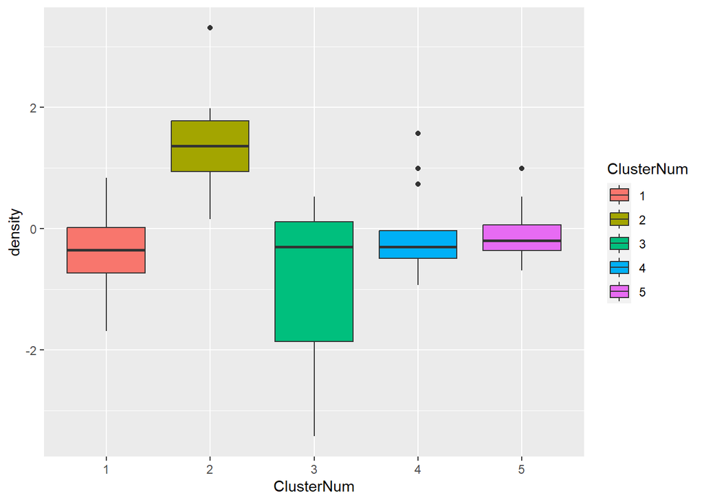

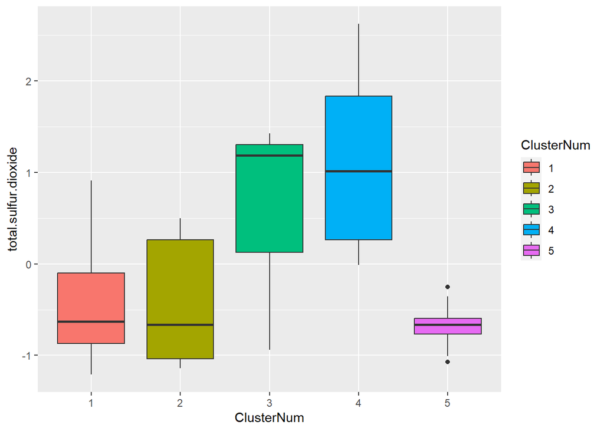

Analizując szerzej otrzymane wyniki możemy zauważyć, że generalnie największe parametry mają wina w klastrach nr 2, 3 lub 4. Możemy również zobaczyć, że klaster nr 5 zawiera najmniej zróżnicowane pod kątem wartości próbki.

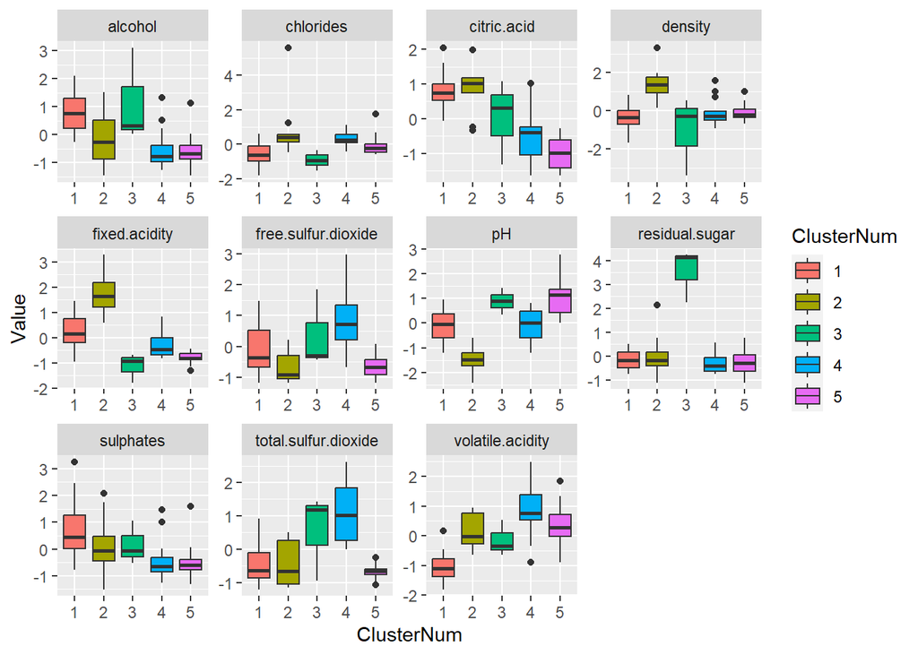

## 5.4 Podsumowanie

W przypadku rozpatrywanego zbioru w obu przypadkach najbardziej optymalny okazał się podział na 5 klastrów. W przypadku analizy hierarchicznej, wyniki można przedstawić w postaci dendrogramu (drzewa binarnego) i na jego podstawie ocenić, jaka liczba grup jest optymalna bez uprzedniej znajomości podziału. W metodzie k-means/k-median musieliśmy z góry założyć liczbę skupień, na jaką chcemy podzielić zbiór, którą potem mogliśmy zweryfikować na podstawie kryteriów: osypiska (inaczej: łokcia), sylwetki (silhouette) i gap.

Dodatkowo odkryliśmy, że dane zawarte w rozważanym fragmencie zbioru były słabo uporządkowane, co szczególnie odbiło się na wynikach metryki gap. Należy jednak zauważyć, że analizy czynników dokonywaliśmy jedynie na niewielkim wycinku badanego zbioru - wyniki uzyskane dla wszystkich obserwacji mogą się różnić; istnieje prawdopodobieństwo, że dla całego zbioru metryka gap dałaby satysfakcjonujące wyniki.